# Estimación de Precios y Análisis de Intermediario Agrícola

Laboratorio SEDESOL

# Objetivo

El mercado alimentario mexicano se debe analizar desde el ámbito de la oferta y de la demanda. El seguimiento de la oferta se realiza mediante predicción de producción agrícola y los movimientos de importación y exportación de alimentos en el territorio nacional. Por otro lado, el análisis de la demanda tiene como objetivo principal medir las fuerzas que afectan los requerimientos del mercado con respecto a un bien o servicio dado un nivel de precios.

“Las fluctuaciones de precios son una característica normal de los mercados agrícolas que funcionan debidamente. Sin embargo, cuando éstas se magnifican y se tornan impredecibles – volátiles – las mismas pueden tener un efecto negativo en la seguridad alimentaria de los consumidores, los productores rurales y países enteros.” [@FAO] El objetivo de este proyecto es analizar el nivel de precios y estimar mediante métodos bayesianos el movimiento de los precios del maiz a nivel estatal en periodos de 3 y 6 meses. Con el vector de precios se utiliza la metodología del indicador IPA (Indicator of price anomalies) [@Baquedano] desarrollado por la fao para para generar un indicador de alerta temprana de crecimiento anómalo en precios de alimentos básicos que pueden impactar en la seguridad alimentaria de la población en situación de pobreza, en esta primera etapa se implementa el análisis para el maíz por la importancia que tiene en el mercado de consumo mexicano especialmente en la población de alta vulnerabilidad y se hace el análisis a nivel nacional."

## Etapas de investigación

- Analizar el nivel de precios y estimar mediante métodos bayesianos el movimiento de los precios del maiz a nivel estatal en periodos de 3 y 6 meses.
- Tener una estrategia analítica de imputación de precios para alimentar la alerta de variación anómala.

# Modelo de Estimación de Precios

```r
##################################################
#### 1. PRECIOS INTERNACIONALES####
##################################################
# tipo de cambio
tipo_cambio <-read_csv("../data/tipo_de_cambio.csv") %>%
  mutate(fecha = dmy(fecha)) %>%
  mutate(año = year(fecha))  %>%
  mutate(mes = month(fecha)) %>%
  select(año,mes,tipo_cambio)
internacional <- read_csv("../data/precio_internacional_dolares.csv") %>%
  separate(Month, c("mes", "año"), " ")  %>%
  mutate(año = as.numeric(año))  %>%
  filter(año>2000) %>%
  mutate(mes = match(mes,month.abb))  %>%
  mutate(fecha = make_datetime(year=año, month=mes, day=1)) %>%
  mutate(fecha= ymd(fecha)) %>%
  rename(int_price = Price) %>%
  left_join(tipo_cambio) %>%
  # Obtenemos el precio por kilogramo (De tonelada) por el tipo de cambio
  mutate(int_price = (int_price*tipo_cambio)/1000) %>%
  select(fecha,año,mes,int_price)
summary(internacional)
```

```
##      fecha                 año            mes           int_price
##  Min.   :2001-01-01   Min.   :2001   Min.   : 1.000   Min.   :0.7564
##  1st Qu.:2004-12-08   1st Qu.:2004   1st Qu.: 3.250   1st Qu.:1.1281
##  Median :2008-11-16   Median :2008   Median : 6.000   Median :2.1282
##  Mean   :2008-11-15   Mean   :2008   Mean   : 6.447   Mean   :2.1444
##  3rd Qu.:2012-10-24   3rd Qu.:2012   3rd Qu.: 9.000   3rd Qu.:2.8363
##  Max.   :2016-10-01   Max.   :2016   Max.   :12.000   Max.   :4.4580
```

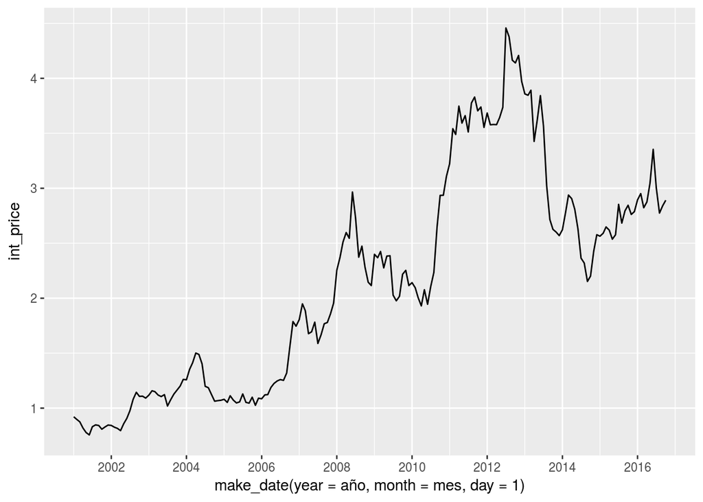

```r
# La base de datos está suficientemente limpia
internacional %>% ggplot() + geom_line(aes(make_date(year=año,month=mes,day=1),int_price))
```

## Obtenemos los precios nacionales promedio por estado

```r
##################################################
#### 2. PRECIOS NACIONALES####
##################################################
#Análisis descriptivo y limpieza de base
nacional <- read_csv("../data/precios_granos_semanales.csv")
problems(nacional)
```

```
## # A tibble: 4 × 4
##     row        col expected actual
##   <int>      <chr>    <chr>  <chr>
## 1  1536 precio_max a double     --
## 2  1536 precio_min a double     --
## 3 12685 precio_max a double     --
## 4 12685 precio_min a double     --
```

```r
glimpse(nacional)
```

```
## Observations: 24,183
## Variables: 9
## $ producto    <chr> "Maiz blanco", "Maiz blanco", "Maiz blanco", "Maiz...
## $ precio_max  <dbl> 6.00, 4.00, 3.60, 6.00, 5.00, 3.50, 3.50, 4.00, 3....
## $ precio_frec <dbl> 4.50, 4.00, 3.50, 5.00, 4.00, 3.33, 3.50, 4.00, 3....
## $ precio_min  <dbl> 4.50, 4.00, 3.10, 4.00, 3.50, 3.33, 3.50, 4.00, 2....
## $ fecha       <chr> "29/12/2010", "29/12/2010", "29/12/2010", "29/12/2...
## $ destino     <chr> "central de abasto de tuxtla gutiérrez", "central ...
## $ origen      <chr> "chiapas", "chihuahua", "durango", "guanajuato", "...
## $ edo_destino <chr> "chiapas", "chihuahua", "durango", "guanajuato", "...
## $ obs         <chr> NA, "COSTAL DE 50 KGS.", "El precio mínimo es para...
```

```r
summary(nacional)
```

```
##    producto           precio_max       precio_frec       precio_min
##  Length:24183       Min.   :  1.500   Min.   : 1.300   Min.   : 1.000
##  Class :character   1st Qu.:  2.500   1st Qu.: 2.500   1st Qu.: 2.400
##  Mode  :character   Median :  4.000   Median : 3.800   Median : 3.700
##                     Mean   :  4.106   Mean   : 3.929   Mean   : 3.789
##                     3rd Qu.:  5.300   3rd Qu.: 5.000   3rd Qu.: 5.000
##                     Max.   :430.000   Max.   :21.000   Max.   :20.000
##                     NA's   :2                          NA's   :2
##     fecha             destino             origen
##  Length:24183       Length:24183       Length:24183
##  Class :character   Class :character   Class :character
##  Mode  :character   Mode  :character   Mode  :character
##
##
##
##
##  edo_destino            obs
##  Length:24183       Length:24183
##  Class :character   Class :character
##  Mode  :character   Mode  :character
##
##
##
##
```

```r
#centrales_abasto <-nacional %>% count(edo_destino,destino) %>% mutate(lat_long = centrales[[destino]][1])

# EL análisis se hará con precios máxico, que es el precio del kilogramo vendido por tonelada.
nacional <-select(nacional,producto,precio_min,fecha,edo_destino,obs) %>%
  #definimos variable de fecha
  mutate(fecha=dmy(fecha))
# Observemos más a fondo el precio por kilogramo vendido en bulto
# identificamos un outlier
quantile(nacional$precio_min,c(.7,.8, .9,.98,.9999,1) ,na.rm = TRUE)
```

```
##    70%    80%    90%    98% 99.99%   100%
##    4.6    5.1    5.8    7.0    8.0   20.0
```

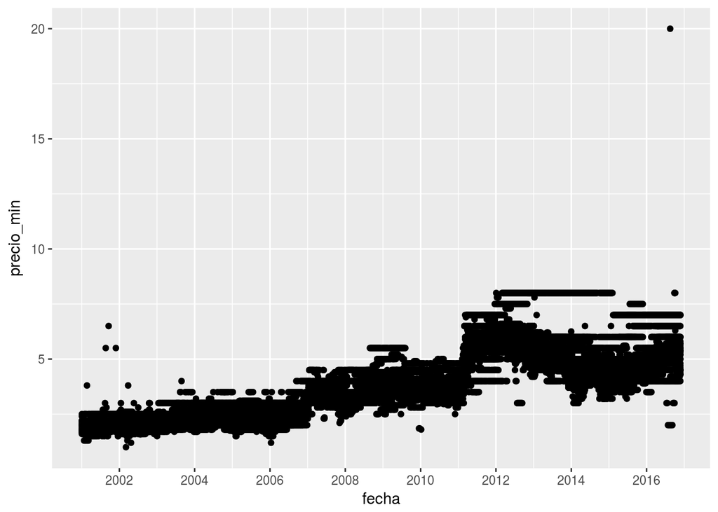

```r
ggplot(nacional) + geom_point(aes(fecha,precio_min))
```

```r
filter(nacional,precio_min > 15)
```

```
## # A tibble: 1 × 5
##      producto precio_min      fecha edo_destino   obs
##         <chr>      <dbl>     <date>       <chr> <chr>
## 1 Maiz blanco         20 2016-08-17  tamaulipas  <NA>
```

```r
# Vemos que ese outlier no tiene observaciones en la columna obs.
# quitamos esa observación para que no perjudique el promedio nacional

estados_dic<- read_csv("../data/estados_dic.csv") %>%
  rename(edo_destino=NOM_ENT) %>%
  mutate(edo_destino = str_to_lower(edo_destino)) %>%
  mutate(CVE_ENT = str_pad(CVE_ENT, 2, pad = "0"))
maiz_nacional <- read_csv("../data/precios_granos_semanales.csv") %>%
  select(producto,fecha,edo_destino,precio_min,obs) %>%
  #definimos variable de fecha
  mutate(fecha=dmy(fecha)) %>%
  #filtramos el outlier
  filter(precio_min < 15) %>%
  arrange(fecha) %>%
  mutate(mes = month(fecha)) %>%
  mutate(año = year(fecha)) %>%
  mutate(fecha = make_datetime(year=año,month=mes,1)) %>%
  mutate(fecha = ymd (fecha)) %>%
  left_join(estados_dic,by = "edo_destino") %>%
    mutate(CVE_ENT = ifelse(edo_destino== "michoacán", "16",
                          ifelse(edo_destino== "veracruz","30",
                                 ifelse(edo_destino=="df","09",
                                        ifelse(edo_destino=="coahuila","05",CVE_ENT)))))
```

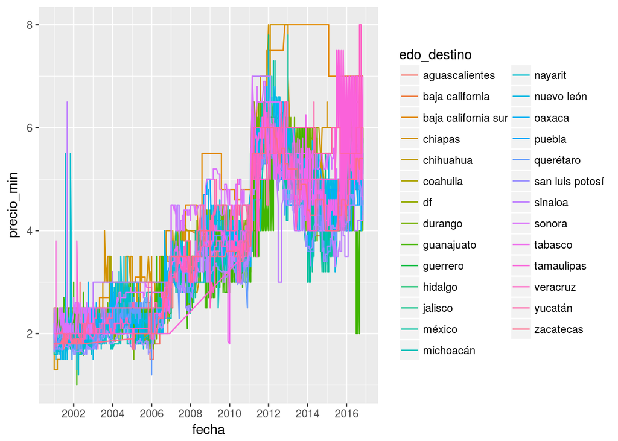

```r
ggplot(maiz_nacional) + geom_line(aes(fecha,precio_min,color=edo_destino))
```

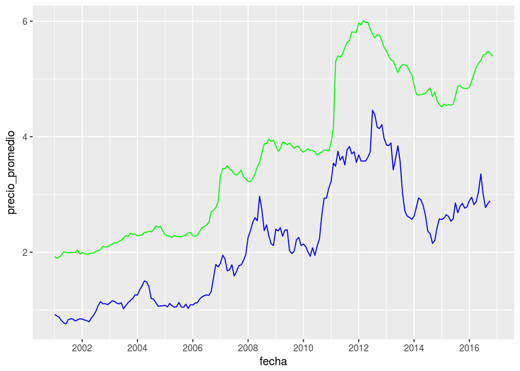

```r
nacional <- maiz_nacional %>%
  group_by(fecha,año,mes) %>%
  summarise(precio_promedio = mean(precio_min, na.rm = TRUE)) %>%
  left_join(internacional,by = c("fecha", "año", "mes"))

nacional %>% ggplot() + geom_line(aes(fecha,precio_promedio),color="green") + geom_line(aes(fecha,int_price),colour="blue")
```

```r
# Obtener una base tipo panel para cada estado del precio por mes del maiz blanco
estatal <- maiz_nacional %>%
  #group_by(CVE_ENT,fecha,año,mes) %>%
  group_by(edo_destino,fecha,año,mes) %>%
  summarise(precio_promedio = mean(precio_min,na.rm=TRUE)) %>%
  #spread(key = CVE_ENT, value = precio_promedio)
  spread(key = edo_destino, value = precio_promedio)


semantic <- left_join(nacional,estatal)
mts <- ts(semantic$precio_promedio, start=c(2001, 1), end=c(2016, 11), frequency=12)
start(mts)
```

```
## [1] 2001    1
```

```r
end(mts)
```

```
## [1] 2016   11
```

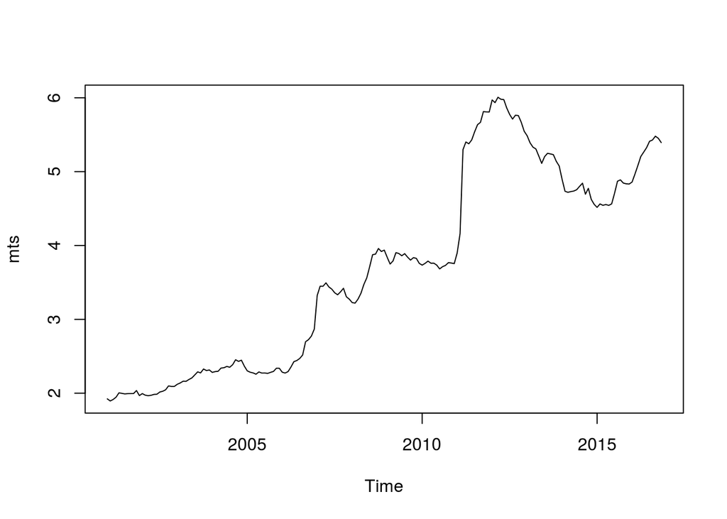

```r
plot(mts)
```

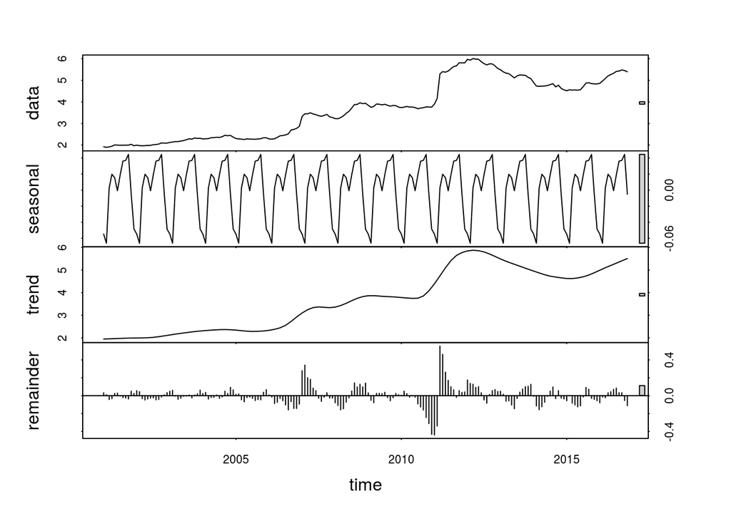

```r
#Seasonal Trend Decomposition
fit = stl(mts, s.window="periodic",t.window=6)
fit = stl(mts, s.window="periodic")
plot(fit)
```

```r
semantic_nacional <- semantic %>% filter(complete.cases(int_price))
semantic_nacional$int_price_lag <- lag(semantic_nacional$int_price)
semantic_nacional <- semantic_nacional %>% filter(complete.cases(int_price_lag))

n<-nrow(semantic_nacional)

dat <- semantic_nacional
semantic_nacional<- mutate(semantic_nacional,l_int_price=dplyr::lag(int_price,n=1))


n<-nrow(semantic_nacional)

# Modelo STAN  [Time series with seasonality]
# La temporada dura 12 meses
dat<-list(N=n,y=semantic_nacional$precio_promedio,x1=semantic_nacional$int_price)
cor(semantic_nacional$precio_promedio,semantic_nacional$int_price)
```

```
## [1] 0.9468547
```

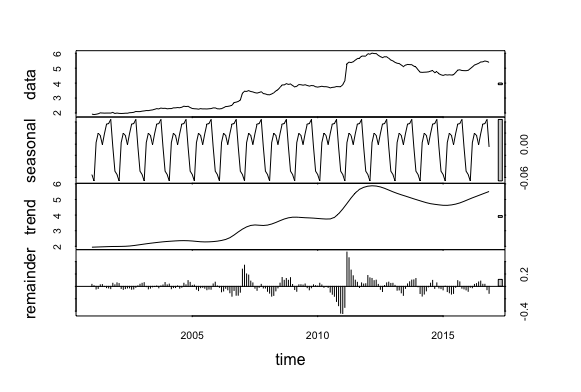

Descomposición de serie de tiempo en estacional y tendencia.

Como primera aproximación se desarrolló un modelo de tendencia de segundo orden con componente estacional. Aunque fue muy interesante observar los resultados de esta aproximación y que pudimos estimar el componente de tendencia y estacionalidad y proyectarlo individualmente el fit no fue lo que estábamos esperando.

$$\begin{aligned}
CV_t &= Q_t + \sum T_t + S_{mod(t,12)} \\
Q_t &=\alpha + \beta f_{1t} + \varepsilon_t \\
T_t - T_{t-1} &= T_{t-1} - T_{t-2} + \varepsilon_t \\
\sum _k ^7 S_k &\sim N(0,\sigma_{S})
\end{aligned}$$

## Modelo estático con Covariable

El siguiente modelo ejecutado fue un modelo estático pero al que se le agregó una especificación polinomial del efecto de la covariable (precios de futuros) y del efecto temporal. Sin embargo no había un proceso de aprendizaje del lag en las covariables y por esta razón se considera estático.

$$\begin{aligned}
p_i &\sim N(\mu_i,\tau) \\
\beta &\sim N(0,0.001) \\
\tau &\sim \gamma(0.001,0.001)\\
\mu_i &= \alpha + \beta_1 f_i +\beta_2f_i^2+\beta_3t_i+\beta_4t_i^2 \\
\end{aligned}$$

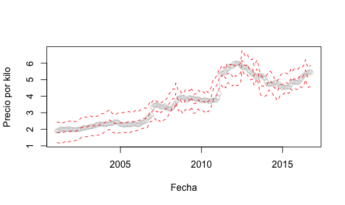

Modelo estático con Covariable

## Modelo Dinámico sin covariables

El siguiente modelo ya es un modelo dinámico en donde las betas se definen con base en su lag y dependen de la variable g que funciona para suavizar el apredizaje. En este modelo no se utiliza la covariable futuros dentro del modelo.

$$\begin{aligned}
p_i &\sim N(\mu_i,\tilde{\tau}) \\
\mu_i &= \beta_i \\
\beta_i &\sim N(\tilde{\mu},\tau) \\
\tilde{\mu} &= g \beta_{i-1} \\
\beta_1 &\sim N(0,0.001) \\
\tau &= \lambda\tilde{\tau} \\
\tilde{\tau} &\sim \gamma(0,0.001) \\
g &\sim N(0,0.001)
\end{aligned}$$

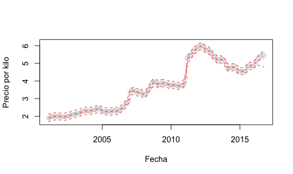

Modelo dinámico sin Covariable

## Modelo Dinámico con covariable

Este último modelo es muy parecido al anterior pero incorpora a la variable de precios de futuros de maiz a la ecuación.

$$\begin{aligned}
p_i &\sim N(\mu_i,\tau) \\
\mu_i &= \alpha + \beta_i f_i \\
\beta_i &\sim N(\beta_{i-1},\hat{\tau}) \\
\beta_1 &\sim N(0,0.001) \\
\hat{\tau} &= \lambda\tau \\
\tau &\sim \gamma(0.001,0.001) \\
\lambda &=10
\end{aligned}$$

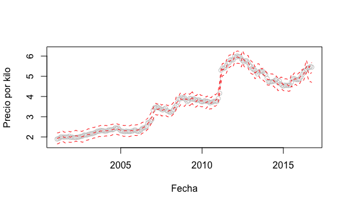

Modelo Dinámico con Covariable

# Interpretación de resultados

Ya que estamos empleando distintas especificaciones no podemos utilizar un método como el DIC por esa razón estimamos varias medidas de error para poder discutir el ajuste. Entre las que se emplearon se encuentran el “Mean absolute error”, “Root mean squared error” y “Mean absolute percentage error”.

Todas ellas contabilizan los errores del vector estimado frente al vector real. Según estas medidas el modelo que mejor ajusta es el modelo 3 que es el modelo dinámico sin covariable.

| Modelo | ME | RMSE | MAE | MPE | MAPE |
| --- | --- | --- | --- | --- | --- |
| 1 | 0.02611729 | 0.1148428 | 0.07487815 | 1.00967 | 2.08551 |
| 2 | 0.01395216 | 0.3103673 | 0.2325069 | 0.3629005 | 6.196993 |
| 3 | 0.01166075 | 0.09974116 | 0.05556027 | 0.4142679 | 1.446658 |
| 4 | 0.014214 | 0.1189785 | 0.07556355 | 0.537999 | 1.996587 |

# Estrategia de Imputación de Precios

Para poder llevar la predicción de precios a nivel municipal es necesario tener una estrategia de imputación a nivel estatal.

## Fuente de Datos 1: Datos de Centrales de Abasto

Esta serie incluye a casi todos los estados del país pero presenta valores nulos en el panel, especialmente en el estado de Guerrero.

Se grafica la ubicación de las centrales:

```r
muni <- read.dbf("~/geom_municipios.dbf")
muni<-tibble::as_data_frame(muni)
muni %>% group_by(CVE_ENT) %>% summarise(n = n()) %>% write.csv("temp.csv")
central_abastos <- read.csv(file = "~/workspace/SEDESOL/politica_preventiva/data/IDW_test/central_abastos_test.csv",
                                      header = TRUE)
central_abastos %>% select(Nombre,precio)
```

```
##                                                      Nombre precio
## 1                             central de abasto de culiacán   2.50
## 2                             central de abasto de ecatepec   1.95
## 3                 central de abasto de guadalupe, nvo. león   1.80
## 4                        central de abasto de iztapalapa df   2.00
## 5                   central de abasto de la laguna, torreón   2.00
## 6                                 central de abasto de león   1.80
## 7                               central de abasto de mérida   2.20
## 8                              central de abasto de pachuca   2.00
## 9                               central de abasto de puebla   1.80
## 10                    central de abasto de tuxtla gutiérrez   2.50
## 11          centro comercial agropecuario de aguascalientes   2.00
## 12                      centro de abasto de san luis potosí   1.66
## 13         centro de distribución y abasto de gómez palacio   2.20
## 14         mercado de abasto 'adolfo lópez mateos' de tepic   1.90
## 15                         mercado de abasto de guadalajara   1.80
## 16                             mercado de abasto de morelia   1.70
## 17                           mercado de abasto de querétaro   1.80
## 18 mercado de abasto "estrella" de san nicolás de los garza   1.85
## 19    mercado de abasto "francisco i. madero" de hermosillo   2.40
## 20               mercado de abasto "olímpico" de hermosillo   2.50
## 21                               módulo de abasto de oaxaca   2.05
## 22           módulo de abasto de tampico, madero y altamira   2.00
## 23                                módulo de abasto irapuato   2.50
## 24                                    nayarabastos de tepic   1.70
## 25                       otros centros mayoristas de xalapa   1.90
## 26                          unión de comerciantes de la paz   2.50
```

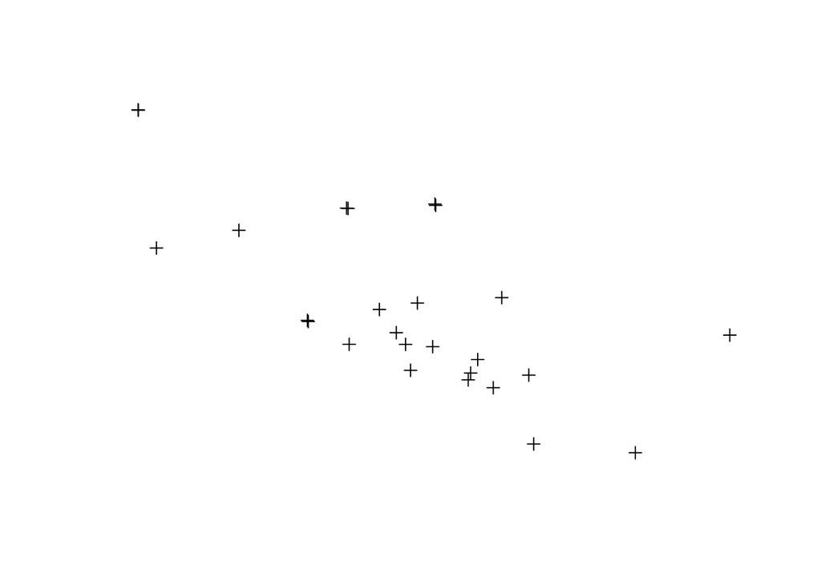

```r
central_abastos$x <- central_abastos$long  # define x & y as longitude and latitude
central_abastos$y <- central_abastos$lat

coordinates(central_abastos) = ~x + y


plot(central_abastos)
```

Se ejecuta un primer Kriging con estos datos

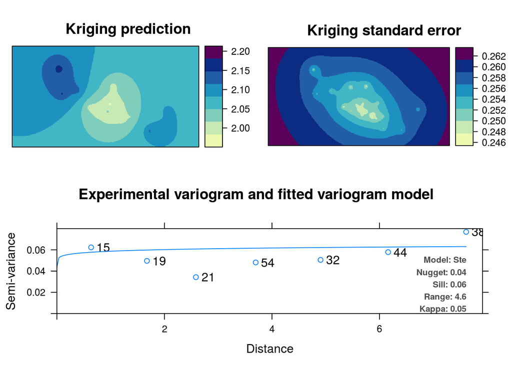

```r
plot(kriging_result)
```

## Fuente de Datos 2: Precio a Pie de Parcela

El precio a pie de parcela es el precio pagado por tonelada al productor, esta información la recolecta SAGARPA a nivel anual presenta valores nulos en el panel.

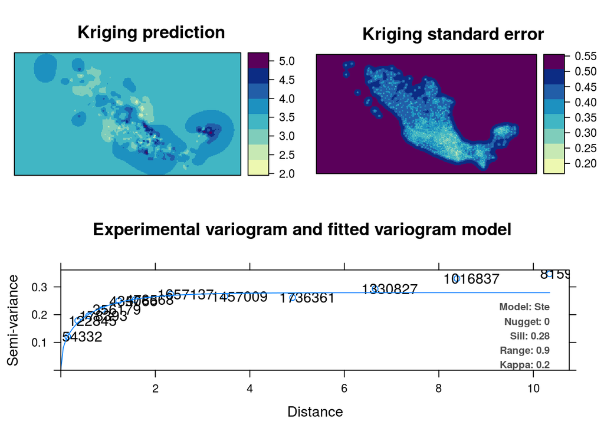

```r
plot(kriging_result)
```